# Response Surface Methods and Designs

A key feature of many response surface designs is splitting the residual error into a pure error term and a lack of fit term. The pure error term is invariant to the specified model as it compares the mean of runs at a specific location with the observed values. This allows testing model misspecification, but isn’t supported by native R, so we will use the `rsm` package (Lenth 2018) in this chapter. The `rsm` package also has facilities for design construction - the [vignette](https://cran.r-project.org/web/packages/rsm/vignettes/rsm.pdf) for the package is a good resource on the many features.

# Example 11.1

An engineer investigating the effect of reaction time and reaction temperature on yield collected the data of Table 11.1. We’ll use `rsm`’s `coded.data` function to encode our data on the $[-1, 1]$ scale, and then fit a first order model using the `FO` helper in the formula. Note that we can use `code2val` to convert coded values to natural units.

```r
library(rsm)

df <- Table11.1
cf <- coded.data(df, x1 ~ (Time - 35) / 5, x2 ~ (Temperature - 155) / 5)
model <- rsm(Yield ~ FO(x1, x2), data=cf)
summary(model)
#
# Call:
# rsm(formula = Yield ~ FO(x1, x2), data = cf)
#
#              Estimate Std. Error  t value  Pr(>|t|)
# (Intercept) 40.444444   0.057288 705.9869 5.451e-16 ***
# x1           0.775000   0.085932   9.0188  0.000104 ***
# x2           0.325000   0.085932   3.7821  0.009158 **
# ---
# Signif. codes:  0 '***' 0.001 '**' 0.01 '*' 0.05 '.' 0.1 ' ' 1
#
# Multiple R-squared:  0.941,   Adjusted R-squared:  0.9213
# F-statistic: 47.82 on 2 and 6 DF,  p-value: 0.0002057
#
# Analysis of Variance Table
#
# Response: Yield
#             Df  Sum Sq Mean Sq F value    Pr(>F)
# FO(x1, x2)   2 2.82500 1.41250 47.8213 0.0002057
# Residuals    6 0.17722 0.02954
# Lack of fit  2 0.00522 0.00261  0.0607 0.9419341
# Pure error   4 0.17200 0.04300
#
# Direction of steepest ascent (at radius 1):
#        x1        x2
# 0.9221944 0.3867267
#
# Corresponding increment in original units:
#        Time Temperature
#    4.610972    1.933633
```

The lack of fit is not significant, but let’s add the two factor interaction in anyway using the `TWI` helper.

```r
model <- rsm(Yield ~ FO(x1, x2) + TWI(x1, x2), data=cf)
summary(model)
#
# Call:
# rsm(formula = Yield ~ FO(x1, x2) + TWI(x1, x2), data = cf)
#
#              Estimate Std. Error  t value  Pr(>|t|)
# (Intercept) 40.444444   0.062311 649.0693 1.648e-13 ***
# x1           0.775000   0.093467   8.2917 0.0004166 ***
# x2           0.325000   0.093467   3.4772 0.0177127 *
# x1:x2       -0.025000   0.093467  -0.2675 0.7997870
# ---
# Signif. codes:  0 '***' 0.001 '**' 0.01 '*' 0.05 '.' 0.1 ' ' 1
#
# Multiple R-squared:  0.9418,  Adjusted R-squared:  0.9069
# F-statistic: 26.97 on 3 and 5 DF,  p-value: 0.00163
#
# Analysis of Variance Table
#
# Response: Yield
#             Df  Sum Sq Mean Sq F value    Pr(>F)
# FO(x1, x2)   2 2.82500 1.41250 40.4213 0.0008188
# TWI(x1, x2)  1 0.00250 0.00250  0.0715 0.7997870
# Residuals    5 0.17472 0.03494
# Lack of fit  1 0.00272 0.00272  0.0633 0.8137408
# Pure error   4 0.17200 0.04300
#
# Stationary point of response surface:
# x1 x2
# 13 31
#
# Stationary point in original units:
#        Time Temperature
#         100         310
#
# Eigenanalysis:
# eigen() decomposition
# $values
# [1]  0.0125 -0.0125
#
# $vectors
#          [,1]       [,2]
# x1 -0.7071068 -0.7071068
# x2  0.7071068 -0.7071068
```

We could fit a second order model using the `SO` helper, but there is no present need.

# Example 11.2

We conduct the test for lack of fit over the linear, linear with interaction, and the full quadratic model, for each of the responses. First, we begin with `Yield`. For `Yield`, the first order model shows lack of fit.

```r
cf <- coded.data(Table11.6, x1 ~ (Time - 85) / 5, x2 ~ (Temperature - 175) / 5)
model <- rsm(Yield ~ FO(x1, x2), data=cf)
summary(model)$lof
# Analysis of Variance Table
#
# Response: Yield
#             Df Sum Sq Mean Sq F value    Pr(>F)
# FO(x1, x2)   2 10.043  5.0215  2.6853 0.1165617
# Residuals   10 18.700  1.8700
# Lack of fit  6 18.488  3.0814 58.1387 0.0007595 ***
# Pure error   4  0.212  0.0530
# ---
# Signif. codes:  0 '***' 0.001 '**' 0.01 '*' 0.05 '.' 0.1 ' ' 1
```

The first order model with interactions shows lack of fit as well.

```r
model <- rsm(Yield ~ FO(x1, x2) + TWI(x1, x2), data=cf)
summary(model)$lof
# Analysis of Variance Table
#
# Response: Yield
#             Df Sum Sq Mean Sq F value   Pr(>F)
# FO(x1, x2)   2 10.043  5.0215  2.4495 0.141472
# TWI(x1, x2)  1  0.250  0.2500  0.1220 0.734960
# Residuals    9 18.450  2.0500
# Lack of fit  5 18.238  3.6476 68.8231 0.000571 ***
# Pure error   4  0.212  0.0530
# ---
# Signif. codes:  0 '***' 0.001 '**' 0.01 '*' 0.05 '.' 0.1 ' ' 1
```

The second order model does not show significant lack of fit.

```r
model <- rsm(Yield ~ SO(x1, x2), data=cf)
summary(model)$lof
# Analysis of Variance Table
#
# Response: Yield
#             Df  Sum Sq Mean Sq  F value    Pr(>F)
# FO(x1, x2)   2 10.0430  5.0215  70.8143 2.267e-05 ***
# TWI(x1, x2)  1  0.2500  0.2500   3.5256    0.1025
# PQ(x1, x2)   2 17.9537  8.9769 126.5944 3.194e-06 ***
# Residuals    7  0.4964  0.0709
# Lack of fit  3  0.2844  0.0948   1.7885    0.2886
# Pure error   4  0.2120  0.0530
# ---
# Signif. codes:  0 '***' 0.001 '**' 0.01 '*' 0.05 '.' 0.1 ' ' 1
```

Next, we examine `Viscosity`. Lack of Fit is no longer significant at the second order model.

```r
model.fo <- rsm(Viscosity ~ FO(x1, x2), data=cf)
model.in <- rsm(Viscosity ~ FO(x1, x2) + TWI(x1, x2), data=cf)
model.so <- rsm(Viscosity ~ SO(x1, x2), data=cf)

rbind(
    'First Order LOF'=summary(model.fo)$lof[3,],
    'First Order Interaction LOF'=summary(model.in)$lof[4,],
    'Second Order LOF'=summary(model.so)$lof[5,]
)
# Analysis of Variance Table
#
# Response: Viscosity
#                             Df Sum Sq Mean Sq F value   Pr(>F)
# First Order LOF              6 343.84  57.307 22.9229 0.004613 **
# First Order Interaction LOF  5 337.59  67.519 27.0075 0.003517 **
# Second Order LOF             3  26.22   8.741  3.4963 0.128988
# ---
# Signif. codes:  0 '***' 0.001 '**' 0.01 '*' 0.05 '.' 0.1 ' ' 1
```

Finally, we examine `MolecularWeight`. Lack of Fit is not significant for the first order model, so we shall use that.

```r
model.fo <- rsm(MolecularWeight ~ FO(x1, x2), data=cf)
model.in <- rsm(MolecularWeight ~ FO(x1, x2) + TWI(x1, x2), data=cf)
model.so <- rsm(MolecularWeight ~ SO(x1, x2), data=cf)

rbind(
    'First Order LOF'=summary(model.fo)$lof[3,],
    'First Order Interaction LOF'=summary(model.in)$lof[4,],
    'Second Order LOF'=summary(model.so)$lof[5,]
)
# Analysis of Variance Table
#
# Response: MolecularWeight
#                             Df Sum Sq Mean Sq F value Pr(>F)
# First Order LOF              6 208591   34765  2.1160 0.2443
# First Order Interaction LOF  5 182991   36598  2.2275 0.2289
# Second Order LOF             3 142150   47383  2.8839 0.1663
```

Constructing the response surface plots is pretty easy with `rsm`. Figure 11.11 gives the response surface for the second order model of `Yield`, which we present below.

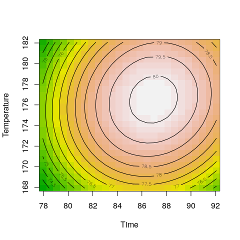

```r
 contour(model, ~ x1 + x2, image = TRUE)
```

# Example 11.3

Note that the `AlgDesign` package uses the Federov exchange algorithm and chooses from a candidate set of points, whereas software like JMP and Design expert use an efficient search algorithm that does not require enumeration of points. As of this time I’m unaware of an R package for constructing such designs, however the existing optimization routines in R are sufficient for such construction.

For both the $D$-optimal design in Table 11.13 and the $I$-optimal design in Table 11.14, a fraction of design space plot was created. The package `Vdgraph` (Lawson 2014) provides the ability to construct such plots. The following is the fraction of design space plot for the $D$-optimal design of Table 11.13.

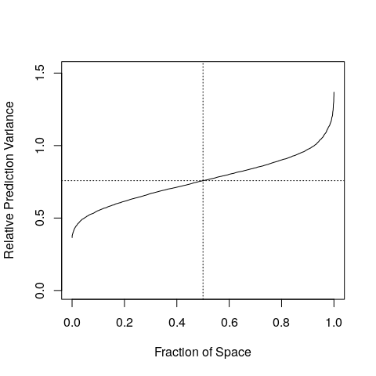

```r
library(Vdgraph)

FDSPlot(Table11.13[,c('X1','X2','X3','X4')], mod=2)
```

Next, we present the fraction of design space plot for the $I$-optimal design of Table 11.14.

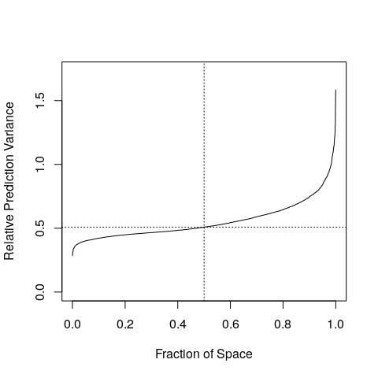

```r
FDSPlot(Table11.14[,c('X1','X2','X3','X4')], mod=2)
```